# Classification of Breast Cancer

Nolan Cardozo

10 February 2017

## Exploring the Breast Cancer dataset to understand its contents.

- **Description:** Predict whether a cancer is malignant or benign from biopsy details.
- **Type:** Binary Classification
- **Dimensions:** 699 instances, 11 attributes
- **Inputs:** Integer (Nominal)
- **Output:** Categorical, 2 class labels (benign/malignant)

The variables in the `Breast Cancer` data set are:

- **Sample code number:** id number
- **Cell thickness:** 1 - 10
- **Uniformity of Cell Size:** 1 - 10
- **Uniformity of Cell Shape:** 1 - 10
- **Marginal Adhesion:** 1 - 10
- **Single Epithelial Cell Size:** 1 - 10
- **Bare Nuclei:** 1 - 10
- **Bland Chromatin:** 1 - 10
- **Normal Nucleoli:** 1 - 10
- **Mitoses:** 1 - 10
- **Class:** benign/malignant

## Loading the dataset in R for analysis.

```r
library(mlbench)
data("BreastCancer")
```

## Viewing the first and last 6 rows of the dataset to verify its contents.

```r
head(BreastCancer)
```

```
##        Id Cl.thickness Cell.size Cell.shape Marg.adhesion Epith.c.size
## 1 1000025            5         1          1             1            2
## 2 1002945            5         4          4             5            7
## 3 1015425            3         1          1             1            2
## 4 1016277            6         8          8             1            3
## 5 1017023            4         1          1             3            2
## 6 1017122            8        10         10             8            7
##   Bare.nuclei Bl.cromatin Normal.nucleoli Mitoses     Class
## 1           1           3               1       1    benign
## 2          10           3               2       1    benign
## 3           2           3               1       1    benign
## 4           4           3               7       1    benign
## 5           1           3               1       1    benign
## 6          10           9               7       1 malignant
```

```r
tail(BreastCancer)
```

```
##         Id Cl.thickness Cell.size Cell.shape Marg.adhesion Epith.c.size
## 694 763235            3         1          1             1            2
## 695 776715            3         1          1             1            3
## 696 841769            2         1          1             1            2
## 697 888820            5        10         10             3            7
## 698 897471            4         8          6             4            3
## 699 897471            4         8          8             5            4
##     Bare.nuclei Bl.cromatin Normal.nucleoli Mitoses     Class
## 694           1           2               1       2    benign
## 695           2           1               1       1    benign
## 696           1           1               1       1    benign
## 697           3           8              10       2 malignant
## 698           4          10               6       1 malignant
## 699           5          10               4       1 malignant
```

## Checking the dimensions of the dataset and the datatypes of its variables.

```r
str(BreastCancer)
```

```
## 'data.frame':    699 obs. of  11 variables:
##  $ Id             : chr  "1000025" "1002945" "1015425" "1016277" ...
##  $ Cl.thickness   : Ord.factor w/ 10 levels "1"<"2"<"3"<"4"<..: 5 5 3 6 4 8 1 2 2 4 ...
##  $ Cell.size      : Ord.factor w/ 10 levels "1"<"2"<"3"<"4"<..: 1 4 1 8 1 10 1 1 1 2 ...
##  $ Cell.shape     : Ord.factor w/ 10 levels "1"<"2"<"3"<"4"<..: 1 4 1 8 1 10 1 2 1 1 ...
##  $ Marg.adhesion  : Ord.factor w/ 10 levels "1"<"2"<"3"<"4"<..: 1 5 1 1 3 8 1 1 1 1 ...
##  $ Epith.c.size   : Ord.factor w/ 10 levels "1"<"2"<"3"<"4"<..: 2 7 2 3 2 7 2 2 2 2 ...
##  $ Bare.nuclei    : Factor w/ 10 levels "1","2","3","4",..: 1 10 2 4 1 10 10 1 1 1 ...
##  $ Bl.cromatin    : Factor w/ 10 levels "1","2","3","4",..: 3 3 3 3 3 9 3 3 1 2 ...
##  $ Normal.nucleoli: Factor w/ 10 levels "1","2","3","4",..: 1 2 1 7 1 7 1 1 1 1 ...
##  $ Mitoses        : Factor w/ 9 levels "1","2","3","4",..: 1 1 1 1 1 1 1 1 5 1 ...
##  $ Class          : Factor w/ 2 levels "benign","malignant": 1 1 1 1 1 2 1 1 1 1 ...
```

## Descriptive statistics to understand the core of the data and its variability.

```r
summary(BreastCancer)
```

```
##       Id             Cl.thickness   Cell.size     Cell.shape
##  Length:699         1      :145   1      :384   1      :353
##  Class :character   5      :130   10     : 67   2      : 59
##  Mode  :character   3      :108   3      : 52   10     : 58
##                     4      : 80   2      : 45   3      : 56
##                     10     : 69   4      : 40   4      : 44
##                     2      : 50   5      : 30   5      : 34
##                     (Other):117   (Other): 81   (Other): 95
##  Marg.adhesion  Epith.c.size  Bare.nuclei   Bl.cromatin  Normal.nucleoli
##  1      :407   2      :386   1      :402   2      :166   1      :443
##  2      : 58   3      : 72   10     :132   3      :165   10     : 61
##  3      : 58   4      : 48   2      : 30   1      :152   3      : 44
##  10     : 55   1      : 47   5      : 30   7      : 73   2      : 36
##  4      : 33   6      : 41   3      : 28   4      : 40   8      : 24
##  8      : 25   5      : 39   (Other): 61   5      : 34   6      : 22
##  (Other): 63   (Other): 66   NA's   : 16   (Other): 69   (Other): 69
##     Mitoses          Class
##  1      :579   benign   :458
##  2      : 35   malignant:241
##  3      : 33
##  10     : 14
##  4      : 12
##  7      :  9
##  (Other): 17
```

## Checking the dataset for missing values using visual heat map from the VIM package.

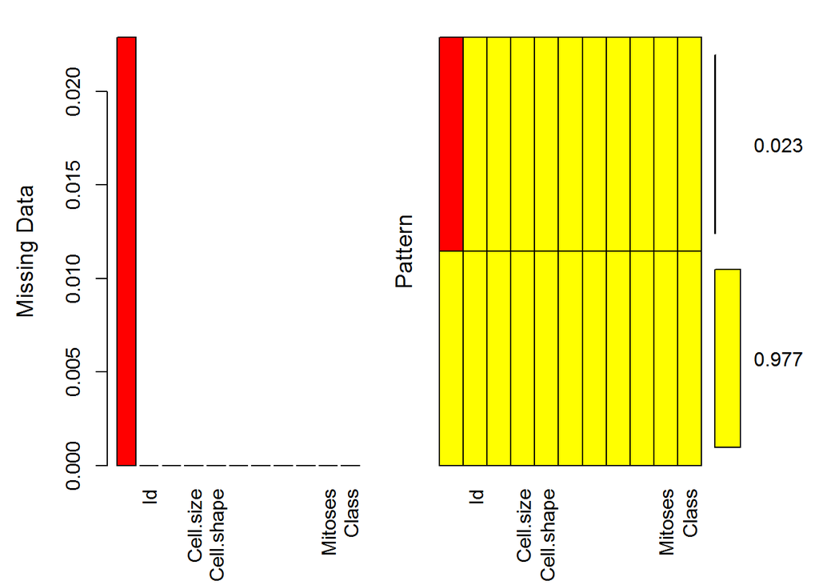

```
##
##  Variables sorted by number of missings:
##         Variable      Count
##      Bare.nuclei 0.02288984
##               Id 0.00000000
##     Cl.thickness 0.00000000
##        Cell.size 0.00000000
##       Cell.shape 0.00000000
##    Marg.adhesion 0.00000000
##     Epith.c.size 0.00000000
##      Bl.cromatin 0.00000000
##  Normal.nucleoli 0.00000000
##          Mitoses 0.00000000
##            Class 0.00000000
```

```r
imputation_plot<-aggr(BreastCancer,col=c('yellow','red'),
                      numbers=TRUE,sortVars=TRUE,
                      labels=names(BreastCancer),gap=3,
                      ylab=c("Missing Data","Pattern"))
```

The above plot and the analysis shows missing values in the dataset

## Imputing missing values using the mice package.

```r
tempdata <- mice(BreastCancer,m=5,maxit=20,meth='cart',seed =100)
```

## Extracting one of the 5 imputed datasets for further analysis.

```r
completeData<-complete(tempdata,4)
```

## Visually checking if values are imputed properly.

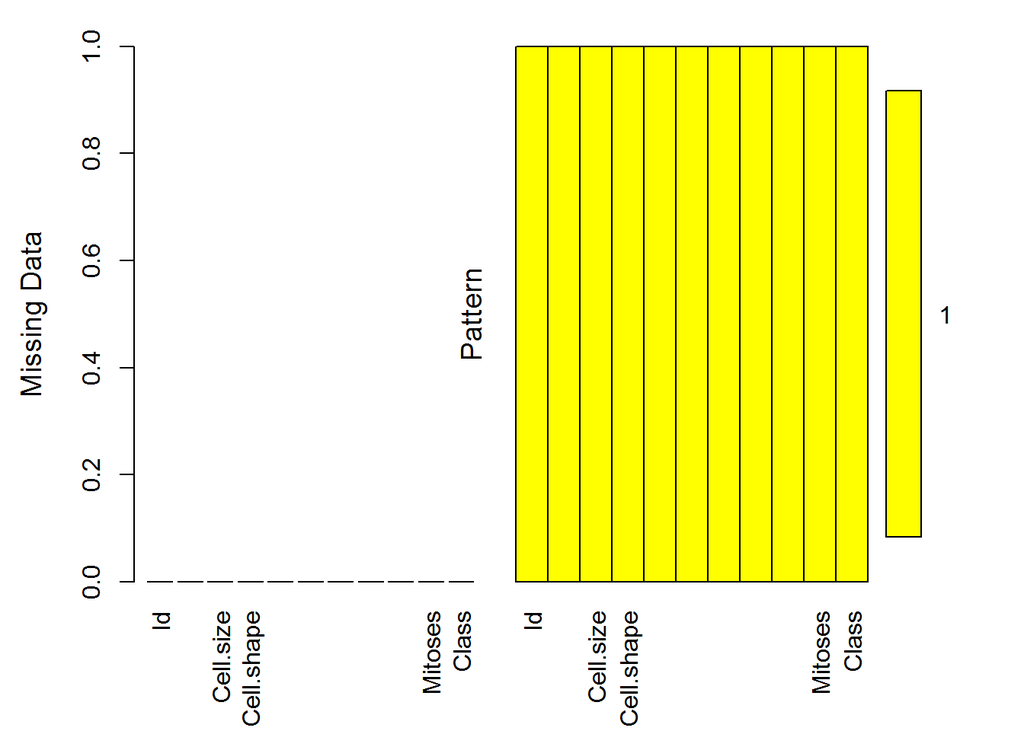

```
##
##  Variables sorted by number of missings:
##         Variable Count
##               Id     0
##     Cl.thickness     0
##        Cell.size     0
##       Cell.shape     0
##    Marg.adhesion     0
##     Epith.c.size     0
##      Bare.nuclei     0
##      Bl.cromatin     0
##  Normal.nucleoli     0
##          Mitoses     0
##            Class     0
```

```r
imputation_plot<-aggr(completeData,col=c('yellow','blue'),
                      numbers=TRUE,sortVars=TRUE,
                      labels=names(completeData),gap=1,
                      ylab=c("Missing Data","Pattern"), plot=TRUE)
```

## Splitting the dataset into training and test set(80-20 split.

```r
set.seed(500)
completeData <- completeData[,-1]
train_no <- sample(1:nrow(completeData),0.8*nrow(completeData))
train <- completeData[train_no,]
test <- completeData[-train_no,]
levels(test) <- levels(train)
```

## 1.Naive Bayes Algorithm

## Building Naive Bayes classification model

```r
model <- naiveBayes(Class ~.,data=train)
model
```

```
##
## Naive Bayes Classifier for Discrete Predictors
##
## Call:
## naiveBayes.default(x = X, y = Y, laplace = laplace)
##
## A-priori probabilities:
## Y
##    benign malignant
## 0.6565295 0.3434705
##
## Conditional probabilities:
##            Cl.thickness
## Y                     1           2           3           4           5
##   benign    0.326975477 0.098092643 0.207084469 0.141689373 0.182561308
##   malignant 0.005208333 0.015625000 0.046875000 0.052083333 0.208333333
##            Cl.thickness
## Y                     6           7           8           9          10
##   benign    0.029972752 0.002724796 0.010899183 0.000000000 0.000000000
##   malignant 0.083333333 0.083333333 0.182291667 0.052083333 0.270833333
##
##            Cell.size
## Y                     1           2           3           4           5
##   benign    0.814713896 0.089918256 0.059945504 0.024523161 0.000000000
##   malignant 0.015625000 0.031250000 0.119791667 0.114583333 0.125000000
##            Cell.size
## Y                     6           7           8           9          10
##   benign    0.002724796 0.002724796 0.002724796 0.002724796 0.000000000
##   malignant 0.104166667 0.072916667 0.109375000 0.015625000 0.291666667
##
##            Cell.shape
## Y                     1           2           3           4           5
##   benign    0.757493188 0.111716621 0.079019074 0.029972752 0.008174387
##   malignant 0.005208333 0.036458333 0.078125000 0.130208333 0.151041667
##            Cell.shape
## Y                     6           7           8           9          10
##   benign    0.005449591 0.005449591 0.002724796 0.000000000 0.000000000
##   malignant 0.104166667 0.098958333 0.114583333 0.031250000 0.250000000
##
##            Marg.adhesion
```

[output cut: 37 more lines]

```
##   benign    0.880108992 0.059945504 0.024523161 0.002724796 0.005449591
##   malignant 0.187500000 0.026041667 0.114583333 0.067708333 0.078125000
##            Normal.nucleoli
## Y                     6           7           8           9          10
##   benign    0.010899183 0.005449591 0.008174387 0.002724796 0.000000000
##   malignant 0.067708333 0.057291667 0.078125000 0.057291667 0.265625000
##
##            Mitoses
## Y                     1           2           3           4           5
##   benign    0.972752044 0.016348774 0.005449591 0.000000000 0.002724796
##   malignant 0.546875000 0.114583333 0.140625000 0.041666667 0.020833333
##            Mitoses
## Y                     6           7           8          10
##   benign    0.000000000 0.002724796 0.000000000 0.000000000
##   malignant 0.010416667 0.041666667 0.026041667 0.057291667
```

## Validating model results with test set and building confusion matrix to calculate accuracy

```r
pred<-predict(model,test[,-10])
conf<-table(pred,test$Class)
conf
```

```
##
## pred        benign malignant
##   benign        90         0
##   malignant      1        49
```

## Accuracy of Naive Bayes Classification model

```r
acc_nb<- as.numeric(format(round(sum(diag(conf))/sum(conf),4),4))
acc_nb
```

```
## [1] 0.9929
```

## 2.Decision tree Algorithms

## Building Ctree classification model and plotting the same

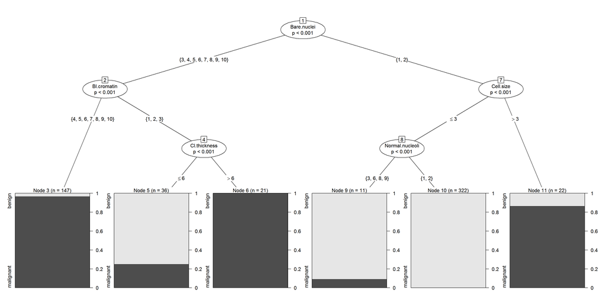

```r
ctree_model <-ctree(Class ~.,data=train)
plot(ctree_model)
```

## Validating model results with test set and building confusion matrix to calculate accuracy

```r
pred_ctree <-predict(ctree_model,test[,-10])
conf_ctree <- table(pred_ctree,test$Class)
conf_ctree
```

```
##
## pred_ctree  benign malignant
##   benign        88         4
##   malignant      3        45
```

## Accuracy of Ctree Classification model

```r
acc_ctree<- as.numeric(format(round(sum(diag(conf_ctree))/sum(conf_ctree),4),4))
acc_ctree
```

```
## [1] 0.95
```

## Building Rpart classification model and plotting the same

```r
rpart_model <- rpart(Class ~.,method="class",data=train)
printcp(rpart_model)
```

```
##
## Classification tree:
## rpart(formula = Class ~ ., data = train, method = "class")
##
## Variables actually used in tree construction:
## [1] Bare.nuclei  Cell.shape   Cell.size    Cl.thickness
##
## Root node error: 192/559 = 0.34347
##
## n= 559
##
##         CP nsplit rel error  xerror     xstd
## 1 0.770833      0   1.00000 1.00000 0.058476
## 2 0.052083      1   0.22917 0.26562 0.035458
## 3 0.015625      2   0.17708 0.18750 0.030227
## 4 0.010417      5   0.13021 0.19792 0.030996
## 5 0.010000      6   0.11979 0.19792 0.030996
```

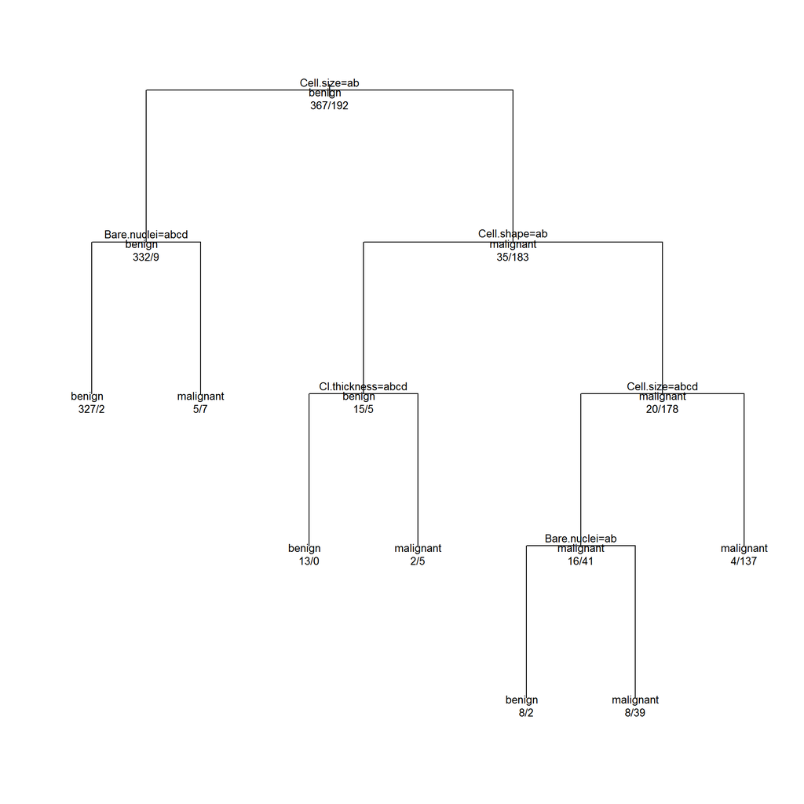

```r
plot(rpart_model,uniform=T)
text(rpart_model,use.n=T,all=T,cex=.8)
```

## Validating model results with test set and building confusion matrix to calculate accuracy

```r
pred_rpart <- predict(rpart_model,test[,-10],type="class")
conf_rpart <- table(pred_rpart,test$Class)
conf_rpart
```

```
##
## pred_rpart  benign malignant
##   benign        85         4
##   malignant      6        45
```

## Accuracy of Rpart Classification model

```r
acc_rpart<- as.numeric(format(round(sum(diag(conf_rpart))/sum(conf_rpart),4),4))
acc_rpart
```

```
## [1] 0.9286
```

## 3.Random Forest Algorithm

## Building Random Forest classification model.

```r
rf_model <- randomForest(Class ~.,data=train,ntree=500)
print(rf_model)
```

```
##
## Call:
##  randomForest(formula = Class ~ ., data = train, ntree = 500)
##                Type of random forest: classification
##                      Number of trees: 500
## No. of variables tried at each split: 3
##
##         OOB estimate of  error rate: 3.04%
## Confusion matrix:
##           benign malignant class.error
## benign       355        12  0.03269755
## malignant      5       187  0.02604167
```

## Validating model results with test set and building confusion matrix to calculate accuracy

```r
pred_rf <-predict(rf_model,test[,-10])
conf_rf <-table(pred_rf,test$Class)
conf_rf
```

```
##
## pred_rf     benign malignant
##   benign        90         2
##   malignant      1        47
```

## Accuracy of Random Forest Classification model

```r
acc_rf<- as.numeric(format(round(sum(diag(conf_rf))/sum(conf_rf),4),4))
acc_rf
```

```
## [1] 0.9786
```

## 3.K Nearest Neighbours(KNN) Algorithm

```r
TrainLabels<- train[,10]
TestLabels<- test[,10]
knnModel<- knn(train[,-10],test[,-10],cl=TrainLabels,k=10,prob=T)
```

## Validating model results with test set and building confusion matrix to calculate accuracy

```r
CrossTable(x=TestLabels,y=knnModel,prop.chisq = F)
```

```
##
##
##    Cell Contents
## |-------------------------|
## |                       N |
## |           N / Row Total |
## |           N / Col Total |
## |         N / Table Total |
## |-------------------------|
##
##
## Total Observations in Table:  140
##
##
##              | knnModel
##   TestLabels |    benign | malignant | Row Total |
## -------------|-----------|-----------|-----------|
##       benign |        90 |         1 |        91 |
##              |     0.989 |     0.011 |     0.650 |
##              |     0.968 |     0.021 |           |
##              |     0.643 |     0.007 |           |
## -------------|-----------|-----------|-----------|
##    malignant |         3 |        46 |        49 |
##              |     0.061 |     0.939 |     0.350 |
##              |     0.032 |     0.979 |           |
##              |     0.021 |     0.329 |           |
## -------------|-----------|-----------|-----------|
## Column Total |        93 |        47 |       140 |
##              |     0.664 |     0.336 |           |
## -------------|-----------|-----------|-----------|
##
##
```

```r
conf_knn1<-table(TestLabels,knnModel)
```

## Accuracy of KNN Classification model

```r
acc_knn<- as.numeric(format(round(sum(diag(conf_knn1))/sum(conf_knn1),4),4))
acc_knn
```

```
## [1] 0.9714
```

## 3.Logistic Regression Algoritm

```r
log <- glm(Class ~ ., family = "binomial", data = train)
summary(log)
```

```
##
## Call:
## glm(formula = Class ~ ., family = "binomial", data = train)
##
## Deviance Residuals:
##        Min          1Q      Median          3Q         Max
## -3.463e-05  -2.100e-08  -2.100e-08   2.100e-08   3.848e-05
##
## Coefficients:
##                     Estimate Std. Error z value Pr(>|z|)
## (Intercept)       -5.566e+01  2.217e+05   0.000    1.000
## Cl.thickness2      1.633e+01  1.796e+05   0.000    1.000
## Cl.thickness3      1.133e+01  1.726e+05   0.000    1.000
## Cl.thickness4      1.554e+01  1.917e+05   0.000    1.000
## Cl.thickness5      1.937e+01  1.714e+05   0.000    1.000
## Cl.thickness6      8.085e+00  1.500e+05   0.000    1.000
## Cl.thickness7      7.149e+01  1.544e+05   0.000    1.000
## Cl.thickness8      3.835e+01  1.519e+05   0.000    1.000
## Cl.thickness9      1.034e+02  3.607e+05   0.000    1.000
## Cl.thickness10     6.746e+01  1.858e+05   0.000    1.000
## Cell.size2         4.067e+00  5.996e+04   0.000    1.000
## Cell.size3         2.806e+01  7.487e+04   0.000    1.000
## Cell.size4        -1.018e+01  1.540e+05   0.000    1.000
## Cell.size5         2.573e+01  2.417e+05   0.000    1.000
## Cell.size6         3.536e+01  2.375e+05   0.000    1.000
## Cell.size7        -2.014e+01  5.220e+05   0.000    1.000
## Cell.size8         2.834e+00  2.066e+05   0.000    1.000
## Cell.size9         3.334e+01  6.516e+05   0.000    1.000
## Cell.size10        7.132e+01  5.143e+05   0.000    1.000
## Cell.shape2       -2.591e+01  8.391e+04   0.000    1.000
## Cell.shape3       -3.712e+00  9.743e+04   0.000    1.000
## Cell.shape4       -1.523e+00  8.095e+04   0.000    1.000
## Cell.shape5        1.948e+01  1.717e+05   0.000    1.000
## Cell.shape6        1.294e+01  1.368e+05   0.000    1.000
## Cell.shape7        7.307e+00  1.880e+05   0.000    1.000
## Cell.shape8        6.196e+01  2.300e+05   0.000    1.000
## Cell.shape9        9.498e+01  5.674e+05   0.000    1.000
## Cell.shape10       1.945e+01  3.338e+05   0.000    1.000
## Marg.adhesion2    -5.655e+00  1.037e+05   0.000    1.000
## Marg.adhesion3    -1.431e+00  6.351e+04   0.000    1.000
```

[output cut: 44 more lines]

[output not shown]

## Validating model results with test set and building confusion matrix to calculate accuracy

```r
pred_log <- round(predict(log, test[,-10], type='response'))
conf_log <-table(pred_log,test$Class)
conf_log
```

```
##
## pred_log benign malignant
##        0     91         8
##        1      0        41
```

## Accuracy of Logistic Regression model

```r
acc_log<- as.numeric(format(round(sum(diag(conf_log))/sum(conf_log),4),4))
acc_log
```

```
## [1] 0.9429
```

## Comparing Model Accuracies of Naive Bayes,Ctree,Rpart,Random Forest,KNN and Logistic Regression Models.

```r
compare <- data.frame("Naive Bayes"=  acc_nb ,"Ctree"=  acc_ctree,"Rpart"=  acc_rpart,"Random_Forest"=  acc_rf,"KNN"=  acc_knn,"Logistic Regression"=  acc_log)
compare
```

```
##   Naive.Bayes Ctree  Rpart Random_Forest    KNN Logistic.Regression
## 1      0.9929  0.95 0.9286        0.9786 0.9714              0.9429
```

### As seen above Naive Bayes Classification Model is the most accurate model with an accuracy of 99.29%